# generics of natural kinds

mht

May 16, 2015

# Prior 1: Prevalence priors for 8 properties

n = 30. 80 responses per subject. [Experiment here](http://stanford.edu/~mtessler/experiments/generics/experiments/real-kinds/prior-1.html)

Subjects are permitted to “go back” and change their prevalence estimate for properties presented earlier in the sequence. The “Animal list” cannot be changed, however.

Subjects are given 5 out of the following 6 animals to initialize the list.

1. Birds
2. Leopards
3. Ducks
4. Lions
5. Mosquitos
6. Sharks

# Response histogram

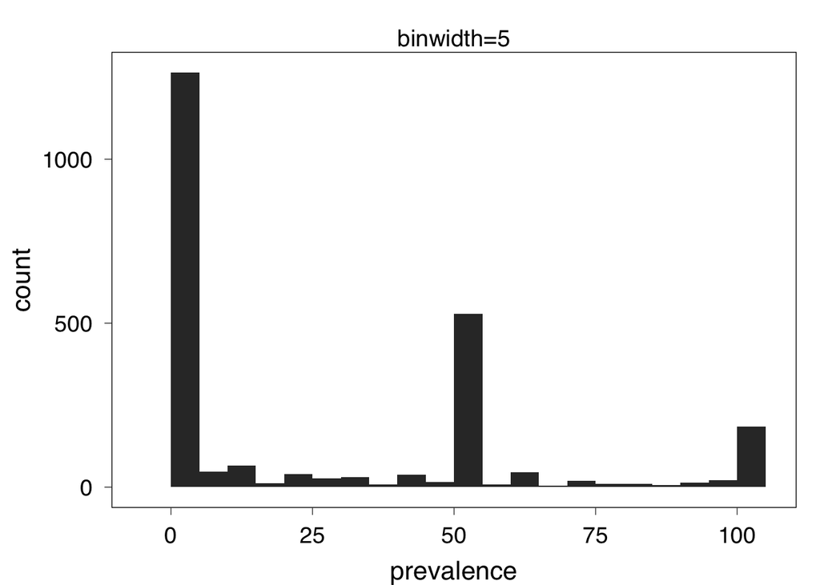

```r
ggplot(d, aes(x=prevalence))+geom_histogram(binwidth=5)+ggtitle('binwidth=5')
```

For each subject:

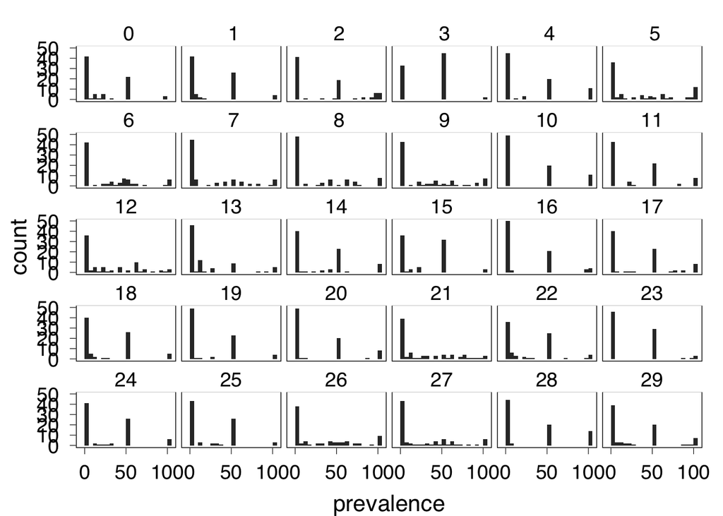

```r
ggplot(d, aes(x=prevalence))+
  geom_histogram(binwidth=5)+
  facet_wrap(~workerid)+
  scale_x_continuous(breaks=c(0, 50, 100))
```

# Animal production data

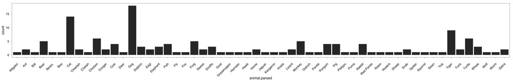

```r
animals.given <- c("Bird","Leopard","Duck","Lion","Mosquito","Shark")

# retrieve novel animals (and count only one instance per subject)
animals.produced<-filter(d,
                         (!(animal.parsed %in% animals.given)&
                            (property_index==0)))


ggplot(animals.produced, aes(x=animal.parsed))+
  geom_histogram()+
  theme(axis.text.x = element_text(angle = 45, hjust = 1))
```

# Prevalence distributions

## Estimates for each animal.

Some of these animals have very few responses, owing to the fact that they were produced by just one or a few subjects. Ordering is alphabetical by animal name. Light blue bars indicate the category of interest for each property (for the generic).

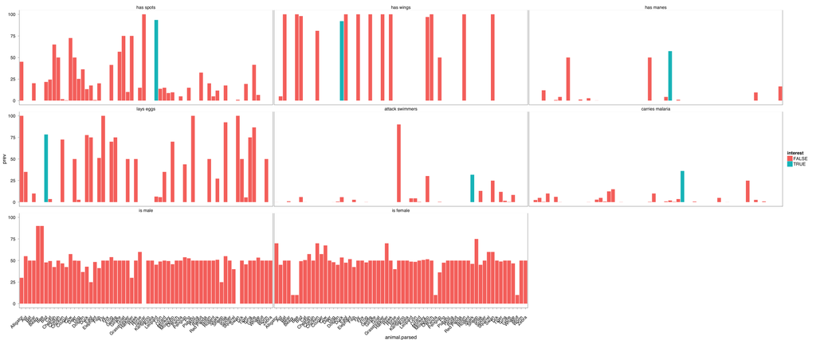

```r
d.tidy<- d %>%
  group_by(property,animal.parsed) %>%
  summarise(prev = mean(prevalence))

generics.of.interest$combined <- paste(generics.of.interest$property,
                                       generics.of.interest$animal)
d.tidy$combined <- paste(d.tidy$property, d.tidy$animal.parsed)

d.tidy$interest<-d.tidy$combined %in% generics.of.interest$combined

ggplot(data=d.tidy, aes(x=animal.parsed, y=prev, fill=interest))+
  geom_bar(stat='identity',position=position_dodge())+
  facet_wrap(~property)+
  theme(axis.text.x = element_text(angle = 45, hjust = 1))
```

Reducing this plot to only the animals that were given to subjects (+ Dog and Cat, which over a third of subjects produced)

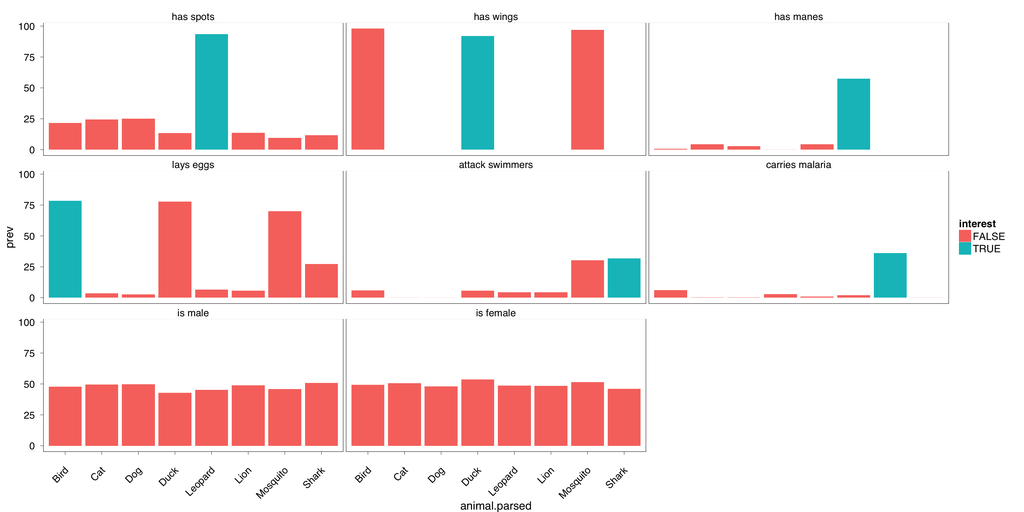

```r
animals.with.at.least10.responses <- c(animals.given, c("Cat","Dog"))

d.tidy.sub<- d.tidy %>% filter(animal.parsed %in%animals.with.at.least10.responses)

ggplot(data=d.tidy.sub, aes(x=animal.parsed, y=prev, fill=interest))+
  geom_bar(stat='identity',position=position_dodge())+
  facet_wrap(~property)+
  theme(axis.text.x = element_text(angle = 45, hjust = 1))
```

## Distribution by animal

Here, I plot the distribution of prevalence after summarizing an average prevalence for each animal. Hence, a sample from this distribution is an animal category (with an associated prevalence of the property). Again note:: many of these categories have very few responses.

Green line indicates prevalence for target category.

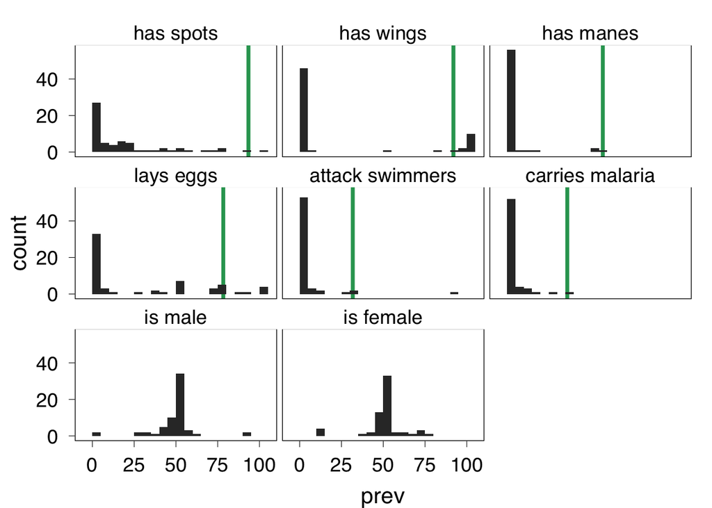

```r
ggplot(data=d.tidy, aes(x=prev))+
  geom_vline(data=filter(d.tidy,interest), aes(xintercept=prev),
             colour='#2ca25f',size=1.3)+
  geom_histogram(binwidth=5)+
  facet_wrap(~property)
```

## Distribution by response

Here, I don’t include the intermediate step of summarising by animal kind. Instead, I just plot the density directly from subjects’ responses. Again, green line indicates prevalence for target categogry.

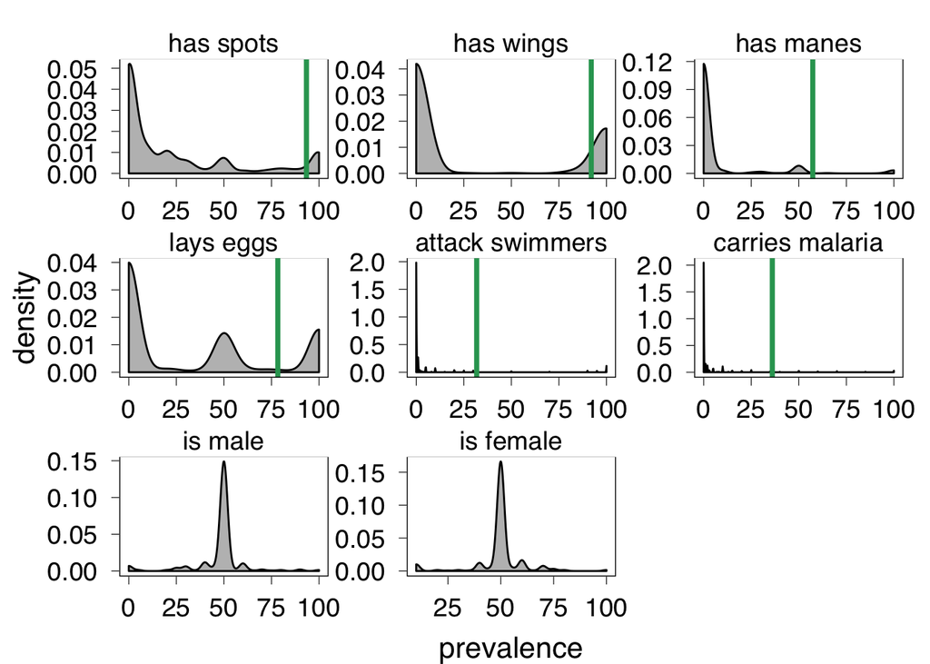

```r
d.interest<-d.tidy %>% filter(interest)

ggplot(data = d, aes(x=prevalence))+
  #geom_histogram()+
  geom_density(adjust=0.5, fill='grey')+
  facet_wrap(~property,scales='free')+
  geom_vline(data=d.interest, aes(xintercept=prev), colour='#2ca25f',size=1.3)
```

Binned distributions (for model)

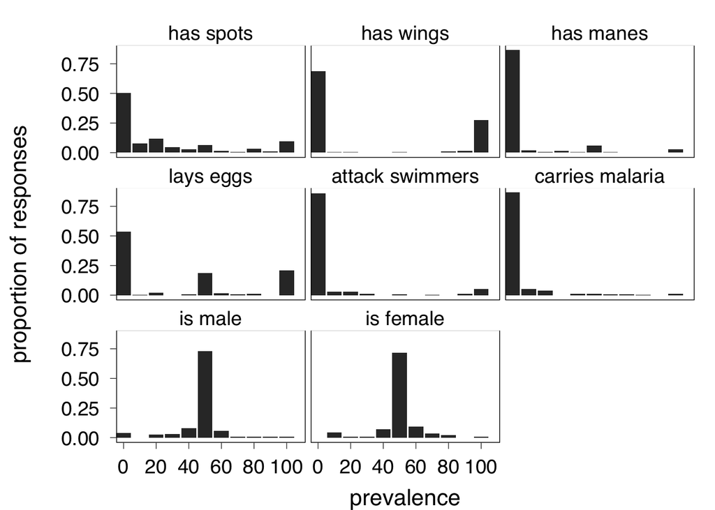

```r
d <- d %>% mutate(roundval=factor(round(prevalence/10)*10))

d.bin<- d %>%
  group_by(property, roundval) %>%
  summarise(count = length(roundval)) %>%
  ungroup() %>% group_by(property) %>%
  mutate(prob = count/sum(count),
         roundval = to.n(roundval))

ggplot(d.bin, aes(x=roundval, y=prob))+
  geom_bar(stat='identity', position=position_dodge())+
  facet_wrap(~property)+
  xlab("prevalence")+
  ylab("proportion of responses\n")+
  #scale_fill_brewer(palette='Pastel1',type='qual')+
 # scale_y_continuous(breaks=c(0,0.25,0.5,0.75,1),limits=c(0,1))+
  scale_x_discrete(breaks=c(0,20,40,60,80,100))+#,limits=c(-5,105))+
 # theme_blackDisplay()+
  guides(fill=guide_legend(title="property"))+
#  theme(legend.key.size=unit(2, "lines"),
#        legend.text.align=NULL)+
  guides(fill=F)
```

```r
filter(d, property=='attack swimmers' & prevalence>90)$animal.parsed
```

```
##  [1] Mosquito Shark    Lion     Tiger    Shark    Mosquito Mosquito
##  [8] Mosquito Shark    Mosquito Mosquito Shark    Bird     Mosquito
## [15] Duck
## 62 Levels: Alligator Ant Bat Bear Bears  Bee Bird Cat Cheetah ... Zebra
```

Looks like “Mosquitos attack swimmers.” is probably true.